# Where jobs and wealth are heading towards? How the way employment and wealth are created has been changing in the last three decades

## Analysing World Bank data from 169 countries in the last 27 years

Date: February, 3rd 2020

Author: David Rodrigues. Github: https://github.com/davidrodriguessp E-mail: davidrodriguessp@hotmail.com Linkedin: linkedin.com/in/davidrodrigues

## 1. Introduction

Ordinary citizens and governments alike are interested in how jobs and wealth are created. Where are the opportunities? Which are the sectors that are growing? The aim of this article is to shed light upon how employment and GDP trends have changed over the years. We have analized different sectors of the economy and found out how the importance of each of them have been growing or decreasing in terms of the jobs and wealth they create.

The data was obtained in the World Bank Global Jobs Indicators Database (JoIn), available in the website https://datacatalog.worldbank.org/dataset/global-jobs-indicators-database. It comprises more than 60 of the standardized labor supply indicators which are most commonly used in country jobs diagnostics. These cover socio-demographics, labor force status and employment type, employment composition by sector and occupation, education level completed, hours worked, and earnings.

Population and employment are shown in thousands, while GDP is presented in constant 2010 million USD. GDP per worker is calculated dividing total GDP and total employment. More details on the variables definitions can be obtained in the website https://development-data-hub-s3-public.s3.amazonaws.com/ddhfiles/160361/jobstructure_tool_demography.pdf.

## 2. Data Preparation

### 2.1 Reading and visualizing the data

```python
# Load required packages
import pandas as pd
import numpy as np
import matplotlib.pyplot as plt
```

```python
# Define url in which raw data is available online
url = 'https://development-data-hub-s3-public.s3.amazonaws.com/ddhfiles/160361/growth-episodes-for-hackathon.xlsx'
```

```python
pip install xlrd # Install program to allow for loading old Excel files
```

```python
# Load the raw datafile
jobs = pd.read_excel(url,0, skiprows=1)
```

### The dataset has 52,687 rows and 193 columns

```python
# Show the number of rows and columns of the datafile
jobs.shape
```

```
(52687, 193)
```

### Each row has information per country and year

```python
# Show the first 5 rows of the dataset
jobs.head()
```

|  | Unnamed: 0 | Country | Start Year | End Year | Period | Years | Region | Income Group | Lending category | Other groups | ... | static contr to change - Agric | static contr to change - Ind | static contr to change - Serv | dynamic contr to change - Total | dynamic contr to change - Agric | dynamic contr to change - Ind | dynamic contr to change - Serv | e yearly growth | p yearly growth | a yearly growth |
| --- | --- | --- | --- | --- | --- | --- | --- | --- | --- | --- | --- | --- | --- | --- | --- | --- | --- | --- | --- | --- | --- |
| 0 | 1 | Afghanistan | 2002 | 2003.0 | 2002-2003 | 1.0 | South Asia | Low income | IDA | HIPC | ... | -0.546384 | 0.471641 | 0.734767 | 0.050424 | 0.002410 | 0.014338 | 0.033676 | 0.138347 | 0.452341 | 0.505678 |
| 1 | 2 | Afghanistan | 2002 | 2004.0 | 2002-2004 | 2.0 | South Asia | Low income | IDA | HIPC | ... | -0.332568 | 0.508920 | 0.291190 | 0.198405 | 0.082260 | 0.072890 | 0.043255 | 0.239981 | 0.428507 | 0.521558 |
| 2 | 3 | Afghanistan | 2002 | 2005.0 | 2002-2005 | 3.0 | South Asia | Low income | IDA | HIPC | ... | -0.460220 | 0.957543 | 0.224806 | 0.221008 | 0.065360 | 0.122068 | 0.033580 | 0.212260 | 0.412807 | 0.555452 |
| 3 | 4 | Afghanistan | 2002 | 2006.0 | 2002-2006 | 4.0 | South Asia | Low income | IDA | HIPC | ... | -0.436945 | 0.960298 | 0.177436 | 0.320849 | 0.082621 | 0.201135 | 0.037092 | 0.189668 | 0.203429 | 0.338012 |
| 4 | 5 | Afghanistan | 2002 | 2007.0 | 2002-2007 | 5.0 | South Asia | Low income | IDA | HIPC | ... | -0.474947 | 0.839135 | 0.336839 | 0.353402 | 0.040149 | 0.192364 | 0.120889 | 0.299515 | 0.077033 | 0.209172 |

5 rows × 193 columns

```python
# Show the last 5 rows of the dataset
jobs.tail()
```

|  | Unnamed: 0 | Country | Start Year | End Year | Period | Years | Region | Income Group | Lending category | Other groups | ... | static contr to change - Agric | static contr to change - Ind | static contr to change - Serv | dynamic contr to change - Total | dynamic contr to change - Agric | dynamic contr to change - Ind | dynamic contr to change - Serv | e yearly growth | p yearly growth | a yearly growth |
| --- | --- | --- | --- | --- | --- | --- | --- | --- | --- | --- | --- | --- | --- | --- | --- | --- | --- | --- | --- | --- | --- |
| 52682 | 52683 | Zimbabwe | 2015 | 2018.0 | 2015-2018 | 3.0 | Sub-Saharan Africa | Lower middle income | Blend | 0 | ... | 0.003619 | -0.065700 | -0.007120 | -0.003660 | 0.000604 | -0.003918 | -0.000347 | 0.186031 | 0.143753 | 0.034545 |
| 52683 | 52684 | Zimbabwe | 2016 | 2017.0 | 2016-2017 | 1.0 | Sub-Saharan Africa | Lower middle income | Blend | 0 | ... | -0.015883 | 0.103593 | 0.228682 | 0.004106 | -0.001241 | -0.000257 | 0.005604 | 0.316837 | 0.110987 | 0.061165 |
| 52684 | 52685 | Zimbabwe | 2016 | 2018.0 | 2016-2018 | 2.0 | Sub-Saharan Africa | Lower middle income | Blend | 0 | ... | 0.000459 | 0.002829 | -0.012184 | -0.000267 | 0.000116 | 0.000191 | -0.000574 | 0.174056 | 0.147617 | 0.174080 |
| 52685 | 52686 | Zimbabwe | 2017 | 2018.0 | 2017-2018 | 1.0 | Sub-Saharan Africa | Lower middle income | Blend | 0 | ... | 0.017656 | -0.095043 | -0.252885 | -0.009395 | 0.002867 | -0.006678 | -0.005584 | 0.030138 | 0.184435 | 0.287724 |
| 52686 | end | -- | -- | NaN | NaN | NaN | NaN | NaN | NaN | NaN | ... | NaN | NaN | NaN | NaN | NaN | NaN | NaN | NaN | NaN | NaN |

5 rows × 193 columns

```python
# Show the first 30 columns
jobs.columns[:30]
```

```
Index(['Unnamed: 0', 'Country', 'Start Year', 'End Year', 'Period', 'Years',
       'Region', 'Income Group', 'Lending category', 'Other groups',
       'Years with Continuous Neg Growth', 'Years with Continuous Pos Growth',
       'Per_Capita_Value_Added_Group_Start',
       'Per_Capita_Value_Added_Group_End', 'Youth_of_Pop_Change_Pos_Neg',
       'WAP_of_Pop_Change_Pos_Neg', 'Urban_Share_Change_Pos_Net',
       'LF_Part_Rate_Change_Pos_Neg', 'Empl_Rate_Change_Pos_Neg',
       'Waged_Empl_Share_Change_Pos_Neg', 'Agric_Empl_Change_Pos_Neg',
       'Ind_Empl_Change_Pos_Neg', 'Serv_Empl_Change_Pos_Neg',
       'Agric_EmplShare_Change_Pos_Neg', 'Ind_EmplShare_Change_Pos_Neg',
       'Serv_EmplShare_Change_Pos_Neg', 'Agric_Prod_Change_Pos_Neg',
       'Ind_Prod_Change_Pos_Neg', 'Serv_Prod_Change_Pos_Neg',
       'Agric_Within_ProdGrowth_Share_Change_Pos_Neg'],
      dtype='object')
```

### 2.2 Slicing and organizing the dataframe

```python
# Select the 16 relevant columns for the analysis and save into a new dataframe 'Sectors'
sectors = jobs.loc[:, ['Country', 'End Year', 'Region', 'Pop_End', 'Empl_Total_End',
                      'Empl_Agric_End', 'Empl_Ind_End', 'Empl_Serv_End','Value_Added_Total_End',
                      'Value_Added_Agric_End', 'Value_Added_Ind_End', 'Value_Added_Serv_End',
                      'Value_Added_per_Worker_Total_End','Value_Added_per_Worker_Agric_End',
                      'Value_Added_per_Worker_Ind_End','Value_Added_per_Worker_Serv_End']]

# Define new names for the columns
newcolumns = ['country', 'year', 'region', 'population', 'empl_total', 'empl_agric', 'empl_ind',
              'empl_serv','gdp_total', 'gdp_agric','gdp_ind', 'gdp_serv', 'gdp_per_worker_total',
              'gdp_per_worker_agric', 'gdp_per_worker_ind', 'gdp_per_worker_serv']

# Rename the columns
sectors.columns = newcolumns

# Show the first 5 rows of the new dataframe 'Sectors'
sectors.head()
```

|  | country | year | region | population | empl_total | empl_agric | empl_ind | empl_serv | gdp_total | gdp_agric | gdp_ind | gdp_serv | gdp_per_worker_total | gdp_per_worker_agric | gdp_per_worker_ind | gdp_per_worker_serv |
| --- | --- | --- | --- | --- | --- | --- | --- | --- | --- | --- | --- | --- | --- | --- | --- | --- |
| 0 | Afghanistan | 2003.0 | South Asia | 23680.871 | 7365.485565 | 4618.085891 | 768.735749 | 1978.663925 | 8124.454292 | 3447.481589 | 1648.237582 | 3028.735121 | 1103.043950 | 746.517425 | 2144.088635 | 1530.697094 |
| 1 | Afghanistan | 2004.0 | South Asia | 24726.684 | 7791.333366 | 4872.232438 | 834.841382 | 2084.259546 | 8239.343661 | 2749.676922 | 1985.968492 | 3503.698247 | 1057.501107 | 564.356680 | 2378.857271 | 1681.027804 |
| 2 | Afghanistan | 2005.0 | South Asia | 25654.277 | 8174.686923 | 5026.042901 | 955.620867 | 2193.023155 | 9164.598459 | 3233.429408 | 2241.977442 | 3689.191608 | 1121.094734 | 643.335020 | 2346.095109 | 1682.240153 |
| 3 | Afghanistan | 2006.0 | South Asia | 26433.049 | 8371.754142 | 5099.654112 | 1023.363224 | 2248.736805 | 9655.582954 | 3100.803742 | 2575.459559 | 3979.319653 | 1153.352426 | 608.041972 | 2516.662214 | 1769.579990 |
| 4 | Afghanistan | 2007.0 | South Asia | 27100.536 | 8581.032264 | 5134.289050 | 1073.916217 | 2372.826996 | 10990.594707 | 3524.381192 | 2746.908398 | 4719.305117 | 1280.801000 | 686.439964 | 2557.842365 | 1988.895577 |

```python
# Show the number of rows and columns of the new dataframe 'Sectors'
sectors.shape
```

```
(52687, 16)
```

### 2.3 Checking for missing values and variable types

```python
# Check for missing values and data type of each variable. There is only 1 mising value
# 'region' and 'country' are of type 'object' and 'year' of type 'float'
sectors.info()
```

```
<class 'pandas.core.frame.DataFrame'>
RangeIndex: 52687 entries, 0 to 52686
Data columns (total 16 columns):
country                 52687 non-null object
year                    52686 non-null float64
region                  52686 non-null object
population              52686 non-null float64
empl_total              52686 non-null float64
empl_agric              52686 non-null float64
empl_ind                52686 non-null float64
empl_serv               52686 non-null float64
gdp_total               52686 non-null float64
gdp_agric               52686 non-null float64
gdp_ind                 52686 non-null float64
gdp_serv                52686 non-null float64
gdp_per_worker_total    52686 non-null float64
gdp_per_worker_agric    52686 non-null float64
gdp_per_worker_ind      52686 non-null float64
gdp_per_worker_serv     52686 non-null float64
dtypes: float64(14), object(2)
memory usage: 6.4+ MB
```

```python
# Drop missing values
sectors.dropna (subset=['year'], inplace=True)

# Show missing values after dropping them
sectors.info()
```

```
<class 'pandas.core.frame.DataFrame'>
Int64Index: 52686 entries, 0 to 52685
Data columns (total 16 columns):
country                 52686 non-null object
year                    52686 non-null float64
region                  52686 non-null object
population              52686 non-null float64
empl_total              52686 non-null float64
empl_agric              52686 non-null float64
empl_ind                52686 non-null float64
empl_serv               52686 non-null float64
gdp_total               52686 non-null float64
gdp_agric               52686 non-null float64
gdp_ind                 52686 non-null float64
gdp_serv                52686 non-null float64
gdp_per_worker_total    52686 non-null float64
gdp_per_worker_agric    52686 non-null float64
gdp_per_worker_ind      52686 non-null float64
gdp_per_worker_serv     52686 non-null float64
dtypes: float64(14), object(2)
memory usage: 6.8+ MB
```

```python
# Change data types of 'country' and 'region' into category
sectors[['country', 'region']] = sectors[['country', 'region']].astype ('category')

# Change 'year' data type into integer
sectors[['year']] = sectors[['year']].astype ('int')

# Show missing values and data types again
sectors.info()
```

```
<class 'pandas.core.frame.DataFrame'>
Int64Index: 52686 entries, 0 to 52685
Data columns (total 16 columns):
country                 52686 non-null category
year                    52686 non-null int64
region                  52686 non-null category
population              52686 non-null float64
empl_total              52686 non-null float64
empl_agric              52686 non-null float64
empl_ind                52686 non-null float64
empl_serv               52686 non-null float64
gdp_total               52686 non-null float64
gdp_agric               52686 non-null float64
gdp_ind                 52686 non-null float64
gdp_serv                52686 non-null float64
gdp_per_worker_total    52686 non-null float64
gdp_per_worker_agric    52686 non-null float64
gdp_per_worker_ind      52686 non-null float64
gdp_per_worker_serv     52686 non-null float64
dtypes: category(2), float64(13), int64(1)
memory usage: 6.2 MB
```

### 2.3.1 Verify if individual countries have values in all years from 1992 to 2018

```python
# Show top-5 countries in terms of GDP
sectors.loc[:,['country', 'gdp_total']][sectors.year==2017].drop_duplicates().sort_values('gdp_total',
                    ascending=False).head()
```

|  | country | gdp_total |
| --- | --- | --- |
| 49515 | United States | 1.734863e+07 |
| 9508 | China | 1.013187e+07 |
| 23975 | Japan | 6.141356e+06 |
| 17817 | Germany | 3.883870e+06 |
| 16890 | France | 2.875308e+06 |

```python
# Build table with GDP data with years in the index and countries in the columns
country_and_year_gdp = pd.pivot_table (sectors, index='year', values= ['gdp_total'], columns =['country'] ,
                                aggfunc='sum', fill_value=np.nan)

# Build table with Boolean results for missing GDP per country per year
country_and_year_gdp_missing = pd.isnull (country_and_year_gdp)
```

```python
# Show table with 'True' values for missing GDP per country per year
# China, Germany or France have GDP data for all years. USA have GDP from 1998 to 2017 and Japan from 1995 to 2017.
country_and_year_gdp_missing.loc[:, [('gdp_total','United States'), ('gdp_total','China'), ('gdp_total','Japan'),
                               ('gdp_total','Germany'), ('gdp_total','France')]]
```

| country year | gdp_total United States | gdp_total China | gdp_total Japan | gdp_total Germany | gdp_total France |
| --- | --- | --- | --- | --- | --- |
| 1992 | True | False | True | False | False |
| 1993 | True | False | True | False | False |
| 1994 | True | False | True | False | False |
| 1995 | True | False | False | False | False |
| 1996 | True | False | False | False | False |
| 1997 | True | False | False | False | False |
| 1998 | False | False | False | False | False |
| 1999 | False | False | False | False | False |
| 2000 | False | False | False | False | False |
| 2001 | False | False | False | False | False |
| 2002 | False | False | False | False | False |
| 2003 | False | False | False | False | False |
| 2004 | False | False | False | False | False |
| 2005 | False | False | False | False | False |
| 2006 | False | False | False | False | False |
| 2007 | False | False | False | False | False |
| 2008 | False | False | False | False | False |
| 2009 | False | False | False | False | False |
| 2010 | False | False | False | False | False |
| 2011 | False | False | False | False | False |
| 2012 | False | False | False | False | False |
| 2013 | False | False | False | False | False |
| 2014 | False | False | False | False | False |
| 2015 | False | False | False | False | False |
| 2016 | False | False | False | False | False |
| 2017 | False | False | False | False | False |
| 2018 | True | False | True | False | False |

```python
# Show top-5 countrie in terms of Employment
sectors.loc[:,['country', 'empl_total']][sectors.year==2017].drop_duplicates().sort_values('empl_total',
                    ascending=False).head()
```

|  | country | empl_total |
| --- | --- | --- |
| 9508 | China | 725641.752983 |
| 21208 | India | 471354.139209 |
| 49515 | United States | 147927.265776 |
| 21586 | Indonesia | 118327.513267 |
| 6016 | Brazil | 88651.303680 |

```python
# Build table with Employment data with years in the index and countries in the columns
country_and_year_empl = pd.pivot_table (sectors, index='year', values= ['empl_total'], columns =['country'] ,
                                aggfunc='sum', fill_value=np.nan)

# Build table with Boolean results for missing Employment per country per year
country_and_year_empl_missing = pd.isnull (country_and_year_empl)
```

```python
# Show table with 'True' values for missing Employment per country per year
# No missing years for China, India, Indonesia or Brazil. USA have data only from 1998 to 2017
country_and_year_empl_missing.loc[:, [('empl_total','China'), ('empl_total','India'), ('empl_total','United States'),
                               ('empl_total','Indonesia'), ('empl_total','Brazil')]]
```

| country year | empl_total China | empl_total India | empl_total United States | empl_total Indonesia | empl_total Brazil |
| --- | --- | --- | --- | --- | --- |
| 1992 | False | False | True | False | False |
| 1993 | False | False | True | False | False |
| 1994 | False | False | True | False | False |
| 1995 | False | False | True | False | False |
| 1996 | False | False | True | False | False |
| 1997 | False | False | True | False | False |
| 1998 | False | False | False | False | False |
| 1999 | False | False | False | False | False |
| 2000 | False | False | False | False | False |
| 2001 | False | False | False | False | False |
| 2002 | False | False | False | False | False |
| 2003 | False | False | False | False | False |
| 2004 | False | False | False | False | False |
| 2005 | False | False | False | False | False |
| 2006 | False | False | False | False | False |
| 2007 | False | False | False | False | False |
| 2008 | False | False | False | False | False |
| 2009 | False | False | False | False | False |
| 2010 | False | False | False | False | False |
| 2011 | False | False | False | False | False |
| 2012 | False | False | False | False | False |
| 2013 | False | False | False | False | False |
| 2014 | False | False | False | False | False |
| 2015 | False | False | False | False | False |
| 2016 | False | False | False | False | False |
| 2017 | False | False | False | False | False |
| 2018 | False | False | True | False | False |

### Based on the missing years for some countries, only 1998 to 2017 will be included for global calculations

### 2.4 Descriptive statistics

Exploratory analysis to verify if data makes sense

```python
# Show descriptive statistics for all numeric variables
# Values seem to make sense
sectors.describe().round(2)
```

|  | year | population | empl_total | empl_agric | empl_ind | empl_serv | gdp_total | gdp_agric | gdp_ind | gdp_serv | gdp_per_worker_total | gdp_per_worker_agric | gdp_per_worker_ind | gdp_per_worker_serv |
| --- | --- | --- | --- | --- | --- | --- | --- | --- | --- | --- | --- | --- | --- | --- |
| count | 52686.00 | 52686.00 | 52686.00 | 52686.00 | 52686.00 | 52686.00 | 52686.00 | 52686.00 | 52686.00 | 52686.00 | 52686.00 | 52686.00 | 52686.00 | 52686.00 |
| mean | 2009.56 | 45179.69 | 18788.06 | 6385.95 | 4244.94 | 8157.17 | 383803.79 | 17451.72 | 115103.78 | 251248.30 | 28294.64 | 20372.38 | 39893.78 | 28055.22 |
| std | 6.27 | 155268.70 | 71192.15 | 29385.45 | 18474.47 | 25945.37 | 1299767.01 | 58806.67 | 377715.15 | 929241.36 | 37785.52 | 116728.14 | 57072.00 | 35718.82 |
| min | 1992.00 | 95.40 | 31.48 | 1.04 | 4.02 | 10.96 | 125.11 | 17.52 | 22.53 | 54.02 | 392.34 | 136.84 | 398.66 | 387.31 |
| 25% | 2005.00 | 3494.20 | 1211.39 | 135.61 | 203.39 | 560.44 | 9677.53 | 962.82 | 2507.63 | 4664.28 | 4446.36 | 1706.92 | 8228.51 | 5646.59 |
| 50% | 2011.00 | 9930.91 | 3944.21 | 681.50 | 621.41 | 1784.41 | 34470.43 | 3251.77 | 10229.56 | 20078.63 | 12821.52 | 5032.83 | 18257.12 | 14426.58 |
| 75% | 2015.00 | 31161.38 | 11678.85 | 3279.04 | 2156.25 | 5273.77 | 236315.79 | 11806.03 | 75742.13 | 141213.67 | 33367.91 | 16071.44 | 40138.81 | 29623.49 |
| max | 2018.00 | 1392730.00 | 725680.19 | 369501.38 | 212878.82 | 322290.37 | 17348626.60 | 772437.65 | 4991134.69 | 13800354.73 | 259932.11 | 3574857.34 | 434344.32 | 266415.97 |

```python
# Show population of China. It is the same as the maximum population
china = sectors[sectors['country']=='China']
china [china.year==2018].drop_duplicates()
```

|  | country | year | region | population | empl_total | empl_agric | empl_ind | empl_serv | gdp_total | gdp_agric | gdp_ind | gdp_serv | gdp_per_worker_total | gdp_per_worker_agric | gdp_per_worker_ind | gdp_per_worker_serv |
| --- | --- | --- | --- | --- | --- | --- | --- | --- | --- | --- | --- | --- | --- | --- | --- | --- |
| 9509 | China | 2018 | East Asia & Pacific | 1392730.0 | 722462.186563 | 193403.13065 | 206768.683858 | 322290.372056 | 1.080057e+07 | 772437.649757 | 4.991135e+06 | 5.036996e+06 | 14949.666007 | 3993.925265 | 24138.736089 | 15628.751237 |

### 2.5 Rounding the results

```python
#Round all variables to the second decimal digit to improve readability
sectors = sectors.round (2)
```

### 2.6 Dropping duplicated data

```python
# Drop duplicated data
sectors.drop_duplicates (inplace=True)

# Show number of rows and columns after dropping duplicates
sectors.shape
```

```
(4041, 16)
```

### 2.7 Checking for unique and extreme values

```python
# Show unique values for the years
sectors.year.unique()
```

```
array([2003, 2004, 2005, 2006, 2007, 2008, 2009, 2010, 2011, 2012, 2013,
       2014, 2015, 2016, 2017, 2018, 1992, 1993, 1994, 1995, 1996, 1997,
       1998, 1999, 2000, 2001, 2002])
```

```python
# Show list of the countries
sectors.country.unique()
```

```
[Afghanistan, Albania, Algeria, Angola, Argentina, ..., Vietnam, West Bank and Gaza, Yemen, Rep., Zambia, Zimbabwe]
Length: 169
Categories (169, object): [Afghanistan, Albania, Algeria, Angola, ..., West Bank and Gaza, Yemen, Rep., Zambia, Zimbabwe]
```

```python
# Show total number of unique countries
sectors.country.nunique()
```

```
169
```

```python
# Show list of the regions. Seven regions are considered
sectors.region.unique()
```

```
[South Asia, Europe & Central Asia, Middle East & North Africa, Sub-Saharan Africa, Latin America & Caribbean, East Asia & Pacific, North America]
Categories (7, object): [South Asia, Europe & Central Asia, Middle East & North Africa, Sub-Saharan Africa, Latin America & Caribbean, East Asia & Pacific, North America]
```

```python
# Show the minimum population in the dataframe
sectors.population.min()
```

```
95.4
```

```python
# Show which country has the smallest population. It is Tonga
sectors[sectors['population']==95.4]
```

|  | country | year | region | population | empl_total | empl_agric | empl_ind | empl_serv | gdp_total | gdp_agric | gdp_ind | gdp_serv | gdp_per_worker_total | gdp_per_worker_agric | gdp_per_worker_ind | gdp_per_worker_serv |
| --- | --- | --- | --- | --- | --- | --- | --- | --- | --- | --- | --- | --- | --- | --- | --- | --- |
| 46875 | Tonga | 1992 | East Asia & Pacific | 95.4 | 31.48 | 10.68 | 9.84 | 10.96 | 258.28 | 69.36 | 42.55 | 146.37 | 8204.23 | 6493.26 | 4324.98 | 13352.66 |

```python
# Show the maximum population. It is 1.3 billion
sectors.population.max()
```

```
1392730.0
```

```python
# Show which country has the largest population. It is China
sectors[sectors['population']==1392730]
```

|  | country | year | region | population | empl_total | empl_agric | empl_ind | empl_serv | gdp_total | gdp_agric | gdp_ind | gdp_serv | gdp_per_worker_total | gdp_per_worker_agric | gdp_per_worker_ind | gdp_per_worker_serv |
| --- | --- | --- | --- | --- | --- | --- | --- | --- | --- | --- | --- | --- | --- | --- | --- | --- |
| 9509 | China | 2018 | East Asia & Pacific | 1392730.0 | 722462.19 | 193403.13 | 206768.68 | 322290.37 | 10800568.39 | 772437.65 | 4991134.69 | 5036996.05 | 14949.67 | 3993.93 | 24138.74 | 15628.75 |

### 2.8 Creating new columns and adding them to the dataframe

New columns were created with the share each segment represents out of total

```python
# Create new variables with each segment employment and GDP share out of total
sectors['agric_share_gdp'] = sectors.gdp_agric.divide(sectors['gdp_total'])
sectors['ind_share_gdp'] = sectors.gdp_ind.divide(sectors['gdp_total'])
sectors['serv_share_gdp'] = sectors.gdp_serv.divide(sectors['gdp_total'])
sectors['agric_share_empl'] = sectors.empl_agric.divide(sectors['empl_total'])
sectors['ind_share_empl'] = sectors.empl_ind.divide(sectors['empl_total'])
sectors['serv_share_empl'] = sectors.empl_serv.divide(sectors['empl_total'])
```

```python
# Show dataframe columns after creating the new variables
sectors.columns
```

```
Index(['country', 'year', 'region', 'population', 'empl_total', 'empl_agric',
       'empl_ind', 'empl_serv', 'gdp_total', 'gdp_agric', 'gdp_ind',
       'gdp_serv', 'gdp_per_worker_total', 'gdp_per_worker_agric',
       'gdp_per_worker_ind', 'gdp_per_worker_serv', 'agric_share_gdp',
       'ind_share_gdp', 'serv_share_gdp', 'agric_share_empl', 'ind_share_empl',
       'serv_share_empl'],
      dtype='object')
```

## 3. Data Analysis

### 3.1 Global GDP and Employment per Sector

Global figures are calculated aggregating numbers from all 169 counties. The table below shows the evolution in terms of GDP and Employment.

```python
# Create a table with global Employment and GDP evolution per year
global_gdp_empl = pd.pivot_table (sectors, index='year', values= ['population', 'gdp_total', 'gdp_agric', 'gdp_ind',
                    'gdp_serv', 'empl_total','empl_agric', 'empl_ind', 'empl_serv'], aggfunc='sum',
                             fill_value=0).loc[1998:2017,:]
# Show the table
global_gdp_empl
```

| year | empl_agric | empl_ind | empl_serv | empl_total | gdp_agric | gdp_ind | gdp_serv | gdp_total | population |
| --- | --- | --- | --- | --- | --- | --- | --- | --- | --- |
| 1998 | 927812.68 | 502582.65 | 885011.75 | 2315407.12 | 1829194.22 | 12768244.42 | 29333651.73 | 43931090.40 | 5618653.70 |
| 1999 | 941733.78 | 506972.01 | 903760.42 | 2352466.18 | 1896183.25 | 13116227.99 | 30327650.84 | 45340062.08 | 5693269.74 |
| 2000 | 956309.78 | 514991.75 | 929147.34 | 2400448.84 | 1965855.25 | 13853782.75 | 31593779.91 | 47413417.85 | 5797778.81 |
| 2001 | 976179.72 | 523026.29 | 960879.14 | 2460085.14 | 2009560.94 | 13887897.43 | 32625308.45 | 48522766.83 | 5935959.15 |
| 2002 | 983000.37 | 525909.51 | 981287.89 | 2490197.69 | 2045990.31 | 14077319.31 | 33437069.42 | 49560379.02 | 6009563.09 |
| 2003 | 991756.44 | 535322.20 | 1010787.56 | 2537866.24 | 2106923.53 | 14599246.58 | 34332921.90 | 51039091.98 | 6124717.27 |
| 2004 | 983457.90 | 554018.70 | 1049860.38 | 2587336.96 | 2204025.30 | 15439278.18 | 35619793.90 | 53263097.36 | 6203884.83 |
| 2005 | 976132.15 | 571652.80 | 1083591.50 | 2631376.49 | 2279052.73 | 15998550.59 | 37036651.69 | 55314255.02 | 6279183.76 |
| 2006 | 960242.23 | 590633.12 | 1122069.94 | 2672945.32 | 2339791.05 | 16857868.60 | 38523473.49 | 57721133.20 | 6360063.12 |
| 2007 | 959781.23 | 609302.24 | 1161593.60 | 2730676.89 | 2387052.13 | 17670731.53 | 40169899.00 | 60227682.57 | 6480989.68 |
| 2008 | 957090.56 | 620482.57 | 1203286.09 | 2780859.17 | 2493775.58 | 18349649.07 | 42143641.72 | 62987066.37 | 6604617.66 |
| 2009 | 948351.80 | 619679.95 | 1229964.11 | 2797995.85 | 2550795.94 | 17446538.80 | 41964839.89 | 61962174.55 | 6712975.41 |
| 2010 | 940412.55 | 631278.36 | 1255781.29 | 2827472.17 | 2623095.34 | 18635348.46 | 43331746.48 | 64590190.38 | 6797590.28 |
| 2011 | 922975.67 | 650029.78 | 1294019.56 | 2867025.00 | 2719998.45 | 19577657.12 | 44811846.96 | 67109502.60 | 6892631.61 |
| 2012 | 905359.95 | 663952.98 | 1328984.99 | 2898297.93 | 2752506.24 | 19977946.05 | 46029181.73 | 68759634.03 | 6975336.56 |
| 2013 | 893355.20 | 675477.05 | 1364302.61 | 2933134.93 | 2887667.37 | 20508839.72 | 47193986.30 | 70590493.32 | 7059237.81 |
| 2014 | 881052.38 | 690022.61 | 1400098.30 | 2971173.34 | 2969336.79 | 21157194.77 | 48478368.88 | 72604900.52 | 7143941.37 |
| 2015 | 872684.68 | 693830.53 | 1423683.97 | 2990199.15 | 3024080.72 | 21575481.76 | 49649139.86 | 74248702.28 | 7190224.34 |
| 2016 | 871093.62 | 699075.74 | 1452735.05 | 3022904.55 | 3086900.14 | 22215837.52 | 50861299.49 | 76164037.25 | 7275503.42 |
| 2017 | 866936.50 | 701542.49 | 1474466.00 | 3042945.01 | 3177534.93 | 22866764.43 | 51895887.88 | 77940187.11 | 7310566.92 |

### We then add the evolution of the segments global share

```python
# Create new columns with the global share per sector for this new table
global_gdp_empl['gdp_share_agric'] = global_gdp_empl.gdp_agric.divide (global_gdp_empl.gdp_total)
global_gdp_empl['gdp_share_ind'] = global_gdp_empl.gdp_ind.divide (global_gdp_empl.gdp_total)
global_gdp_empl['gdp_share_serv'] = global_gdp_empl.gdp_serv.divide (global_gdp_empl.gdp_total)
global_gdp_empl['empl_share_agric'] = global_gdp_empl.empl_agric.divide (global_gdp_empl.empl_total)
global_gdp_empl['empl_share_ind'] = global_gdp_empl.empl_ind.divide (global_gdp_empl.empl_total)
global_gdp_empl['empl_share_serv'] = global_gdp_empl.empl_serv.divide (global_gdp_empl.empl_total)
```

### The table below includes the new columns with the global segments share

```python
# Show the table with the new variables
global_gdp_empl
```

| year | empl_agric | empl_ind | empl_serv | empl_total | gdp_agric | gdp_ind | gdp_serv | gdp_total | population | gdp_share_agric | gdp_share_ind | gdp_share_serv | empl_share_agric | empl_share_ind | empl_share_serv |
| --- | --- | --- | --- | --- | --- | --- | --- | --- | --- | --- | --- | --- | --- | --- | --- |
| 1998 | 927812.68 | 502582.65 | 885011.75 | 2315407.12 | 1829194.22 | 12768244.42 | 29333651.73 | 43931090.40 | 5618653.70 | 0.041638 | 0.290643 | 0.667720 | 0.400713 | 0.217060 | 0.382227 |
| 1999 | 941733.78 | 506972.01 | 903760.42 | 2352466.18 | 1896183.25 | 13116227.99 | 30327650.84 | 45340062.08 | 5693269.74 | 0.041821 | 0.289286 | 0.668893 | 0.400318 | 0.215507 | 0.384176 |
| 2000 | 956309.78 | 514991.75 | 929147.34 | 2400448.84 | 1965855.25 | 13853782.75 | 31593779.91 | 47413417.85 | 5797778.81 | 0.041462 | 0.292191 | 0.666347 | 0.398388 | 0.214540 | 0.387072 |
| 2001 | 976179.72 | 523026.29 | 960879.14 | 2460085.14 | 2009560.94 | 13887897.43 | 32625308.45 | 48522766.83 | 5935959.15 | 0.041415 | 0.286214 | 0.672371 | 0.396807 | 0.212605 | 0.390588 |
| 2002 | 983000.37 | 525909.51 | 981287.89 | 2490197.69 | 2045990.31 | 14077319.31 | 33437069.42 | 49560379.02 | 6009563.09 | 0.041283 | 0.284044 | 0.674673 | 0.394748 | 0.211192 | 0.394060 |
| 2003 | 991756.44 | 535322.20 | 1010787.56 | 2537866.24 | 2106923.53 | 14599246.58 | 34332921.90 | 51039091.98 | 6124717.27 | 0.041281 | 0.286040 | 0.672679 | 0.390784 | 0.210934 | 0.398282 |
| 2004 | 983457.90 | 554018.70 | 1049860.38 | 2587336.96 | 2204025.30 | 15439278.18 | 35619793.90 | 53263097.36 | 6203884.83 | 0.041380 | 0.289868 | 0.668752 | 0.380104 | 0.214127 | 0.405769 |
| 2005 | 976132.15 | 571652.80 | 1083591.50 | 2631376.49 | 2279052.73 | 15998550.59 | 37036651.69 | 55314255.02 | 6279183.76 | 0.041202 | 0.289230 | 0.669568 | 0.370959 | 0.217245 | 0.411796 |
| 2006 | 960242.23 | 590633.12 | 1122069.94 | 2672945.32 | 2339791.05 | 16857868.60 | 38523473.49 | 57721133.20 | 6360063.12 | 0.040536 | 0.292057 | 0.667407 | 0.359245 | 0.220967 | 0.419788 |
| 2007 | 959781.23 | 609302.24 | 1161593.60 | 2730676.89 | 2387052.13 | 17670731.53 | 40169899.00 | 60227682.57 | 6480989.68 | 0.039634 | 0.293399 | 0.666967 | 0.351481 | 0.223132 | 0.425387 |
| 2008 | 957090.56 | 620482.57 | 1203286.09 | 2780859.17 | 2493775.58 | 18349649.07 | 42143641.72 | 62987066.37 | 6604617.66 | 0.039592 | 0.291324 | 0.669084 | 0.344171 | 0.223126 | 0.432703 |
| 2009 | 948351.80 | 619679.95 | 1229964.11 | 2797995.85 | 2550795.94 | 17446538.80 | 41964839.89 | 61962174.55 | 6712975.41 | 0.041167 | 0.281568 | 0.677265 | 0.338940 | 0.221473 | 0.439588 |
| 2010 | 940412.55 | 631278.36 | 1255781.29 | 2827472.17 | 2623095.34 | 18635348.46 | 43331746.48 | 64590190.38 | 6797590.28 | 0.040611 | 0.288517 | 0.670872 | 0.332598 | 0.223266 | 0.444136 |
| 2011 | 922975.67 | 650029.78 | 1294019.56 | 2867025.00 | 2719998.45 | 19577657.12 | 44811846.96 | 67109502.60 | 6892631.61 | 0.040531 | 0.291727 | 0.667742 | 0.321928 | 0.226726 | 0.451346 |
| 2012 | 905359.95 | 663952.98 | 1328984.99 | 2898297.93 | 2752506.24 | 19977946.05 | 46029181.73 | 68759634.03 | 6975336.56 | 0.040031 | 0.290548 | 0.669422 | 0.312376 | 0.229084 | 0.458540 |
| 2013 | 893355.20 | 675477.05 | 1364302.61 | 2933134.93 | 2887667.37 | 20508839.72 | 47193986.30 | 70590493.32 | 7059237.81 | 0.040907 | 0.290533 | 0.668560 | 0.304574 | 0.230292 | 0.465135 |
| 2014 | 881052.38 | 690022.61 | 1400098.30 | 2971173.34 | 2969336.79 | 21157194.77 | 48478368.88 | 72604900.52 | 7143941.37 | 0.040897 | 0.291402 | 0.667701 | 0.296533 | 0.232239 | 0.471227 |
| 2015 | 872684.68 | 693830.53 | 1423683.97 | 2990199.15 | 3024080.72 | 21575481.76 | 49649139.86 | 74248702.28 | 7190224.34 | 0.040729 | 0.290584 | 0.668687 | 0.291848 | 0.232035 | 0.476117 |
| 2016 | 871093.62 | 699075.74 | 1452735.05 | 3022904.55 | 3086900.14 | 22215837.52 | 50861299.49 | 76164037.25 | 7275503.42 | 0.040530 | 0.291684 | 0.667786 | 0.288164 | 0.231260 | 0.480576 |
| 2017 | 866936.50 | 701542.49 | 1474466.00 | 3042945.01 | 3177534.93 | 22866764.43 | 51895887.88 | 77940187.11 | 7310566.92 | 0.040769 | 0.293389 | 0.665842 | 0.284900 | 0.230547 | 0.484552 |

As we can see in the figure below, global GDP reaches close to 80 trillion U.S. dollars in 2017, while the total number of employed workers surpasses 3 billion.

```
array([<matplotlib.axes._subplots.AxesSubplot object at 0x119860ef0>,
      dtype=object)
```

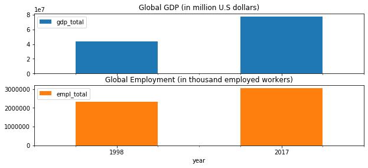

```python
# Create a plot comparing global GDP and Employment in 1998 and 2017
global_gdp_empl.loc[[1998,2017], ['gdp_total', 'empl_total']].plot (kind='bar', subplots=True,
        figsize = (10,4.1), rot=0, title = ['Global GDP (in million U.S dollars)',
        'Global Employment (in thousand employed workers)'])
```

In the following figure, we observe that the services sector is the largest in terms of its capacity to generate jobs and wealth worldwide. It tends to create relatively more GDP than expected considering its participation in terms of employment. The sector employes half of the sales force, but it is able to generate nearly 70% of global GDP.

Agriculture depicts the opposite dynamics. It relativelly employs more people than the wealth it generates. This might be related to public programs of incentive which tend to heavily tax imported goods and protect local production. These initiatives are genuine and can have a positive impact in protecting jobs. On the other hand, they might at some extent reduce competitiveness. This sector employes nearly a third of workers worldwide, although it produces less than 5% of global GDP.

The industry is a more balanced sector in terms of employment and GDP. It accounts for a third of global GDP and a quarter of jobs generated globally.

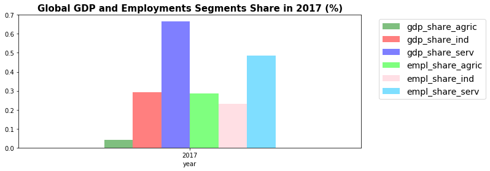

```python
# plot comparing global GDP and Employment Shares in 2017
global_gdp_empl.loc[[2017],['gdp_share_agric', 'gdp_share_ind', 'gdp_share_serv', 'empl_share_agric',
        'empl_share_ind', 'empl_share_serv']].plot (kind='bar', figsize = (10,4), rot=0,
        color = ['green', 'red', 'blue', 'lime','pink', 'deepskyblue'], alpha = 0.5,
        ylim = (0,0.7)).legend(bbox_to_anchor=(1.04,1), loc="upper left", fontsize = 14)
plt.title ( 'Global GDP and Employments Segments Share in 2017 (%)', fontweight='bold', fontsize = 15)
```

### 3.1.2 Global Sector Trends in terms of GDP and Employment

Global GDP presents a sharp drop in 2009, what may be a reflexion of the global financial crisis that started in 2007-2008. At that time, a turmoil in the U.S. housing market contaminated global financial markets and ended up triggering one of the biggest financial crisis of recent history. This decline in 2009 is also confirmed by other reports elaborated by the World Bank (e.g., https://data.worldbank.org/indicator/NY.GDP.MKTP.KD).

It is also worth noticing that, in terms of GDP, the agriculture sector is pretty much stable along the years.

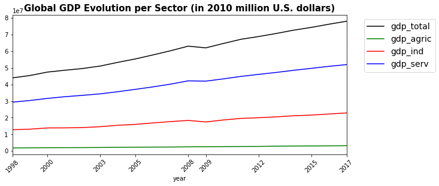

```python
import matplotlib.pyplot as plt
global_gdp_empl[['gdp_total', 'gdp_agric', 'gdp_ind', 'gdp_serv']].plot(color=['black','green', 'red', 'blue'],
                rot=45, xticks=[1998, 2000, 2003, 2005, 2008, 2009, 2012, 2015,2017], figsize = (10,4.3)).legend(bbox_to_anchor=(1.04,1),
                loc="upper left", fontsize = 14)
plt.title ( 'Global GDP Evolution per Sector (in 2010 million U.S. dollars)', fontweight='bold', fontsize = 15)
```

As we can notice in the figure below, employment trends tell a slightly different story. Services still seem to be the sector driving the growth over the years. On the other hand, employment seem to be increasingly migrating from agriculture and industry into services.

Despite the agriculture sector GDP stability, it has been employing less and less people. This reveals a growing productivity of labor, what might be a consequence of increasing automation and use of technology in production.

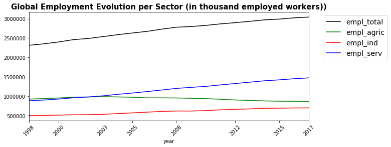

```python
#2002 agriculture and services crossed and 2003 services led for the first time.
empl_evolution=global_gdp_empl[['empl_total', 'empl_agric', 'empl_ind', 'empl_serv']].plot(color=['black','green',
                        'red', 'blue'], rot=45, xticks=[1998, 2000, 2003, 2005, 2008, 2012, 2015,2017],
                        figsize = (10,4)).legend(bbox_to_anchor=(1.04,1), loc="upper left", fontsize = 14)
plt.title ( 'Global Employment Evolution per Sector (in thousand employed workers))', fontweight='bold', fontsize = 15)
```

The period that encompasses the late 90's and early 2000's seems to have been strongly impacted by a revolution in technology. Technology has created new ways for people to provide services and make money. It has increasingly facilitated communication and allowed for new business models to be created including ridesharing, new ways of delivering products and content streaming.

Google was founded in 1998 (https://en.wikipedia.org/wiki/Google), Amazon in 1994 (https://en.wikipedia.org/wiki/History_of_Amazon) and Facebook in 2004 (https://en.wikipedia.org/wiki/History_of_Facebook). The first Iphone was launched by Apple in 2007 (https://en.wikipedia.org/wiki/History_of_iPhone) and Uber was founded in 2009 in San Francisco (https://en.wikipedia.org/wiki/Uber#History) with a huge impact in transportation, offering a new way for people to make money as drivers. All of these new possibilities created by the advances in technology might have fostered how the services sector evolved over the years.

In 2017, almost 1 out of 2 jobs were already related to the service sector, while the importance of agriculture in terms of jobs has been continuously decreasing year after year.

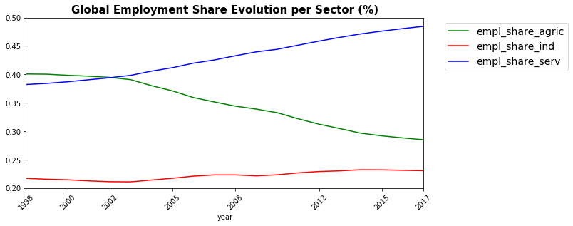

```python
#Agriculture and Services employment share crossed in 2002 and in 2003 Services led for the first time.
empl_share_evolution = global_gdp_empl[['empl_share_agric', 'empl_share_ind', 'empl_share_serv']].plot(color=['green',
                'red', 'blue'], rot=45, xticks=[1998, 2000, 2002, 2005, 2008, 2012, 2015,2017],
                figsize= (10,4.4), ylim = (0.2, 0.5)).legend(bbox_to_anchor=(1.04,1), loc="upper left", fontsize = 14)
plt.title ('Global Employment Share Evolution per Sector (%)', fontweight = 'bold', fontsize = 15)
```

### 3.2 Regional Importance of the Sectors in terms of Employment

The table below presents how the services sector share in terms of employment have been evolving in different parts of the world.

```python
# Table with the Services Share evolution in terms of employment per region
import numpy as np
sector_per_region = pd.pivot_table (sectors, index='year', values= ['serv_share_empl'], columns =['region'] ,
                                aggfunc='mean', fill_value=np.nan).loc[1998:2017,:]
sector_per_region
```

| region year | serv_share_empl East Asia & Pacific | serv_share_empl Europe & Central Asia | serv_share_empl Latin America & Caribbean | serv_share_empl Middle East & North Africa | serv_share_empl North America | serv_share_empl South Asia | serv_share_empl Sub-Saharan Africa |
| --- | --- | --- | --- | --- | --- | --- | --- |
| 1998 | 0.462788 | 0.553039 | 0.572392 | 0.542970 | 0.729130 | 0.309516 | 0.311128 |
| 1999 | 0.457921 | 0.559238 | 0.575770 | 0.546051 | 0.731700 | 0.311721 | 0.312589 |
| 2000 | 0.460144 | 0.564521 | 0.579985 | 0.551509 | 0.739590 | 0.313951 | 0.313472 |
| 2001 | 0.456178 | 0.572019 | 0.582954 | 0.562087 | 0.747520 | 0.318286 | 0.315562 |
| 2002 | 0.462329 | 0.577826 | 0.588591 | 0.569153 | 0.757130 | 0.324987 | 0.320876 |
| 2003 | 0.467249 | 0.584612 | 0.594877 | 0.566772 | 0.760490 | 0.323296 | 0.329509 |
| 2004 | 0.475179 | 0.586735 | 0.595559 | 0.566582 | 0.761610 | 0.328595 | 0.332435 |
| 2005 | 0.481142 | 0.591351 | 0.598398 | 0.568030 | 0.763060 | 0.333993 | 0.335302 |
| 2006 | 0.485952 | 0.595004 | 0.601122 | 0.570577 | 0.762600 | 0.340703 | 0.342705 |
| 2007 | 0.484706 | 0.598662 | 0.605276 | 0.571809 | 0.765740 | 0.344480 | 0.341949 |
| 2008 | 0.492267 | 0.604445 | 0.609586 | 0.581196 | 0.768995 | 0.346739 | 0.340467 |
| 2009 | 0.503267 | 0.618344 | 0.613738 | 0.586736 | 0.781880 | 0.355008 | 0.347597 |
| 2010 | 0.511490 | 0.624232 | 0.616791 | 0.587138 | 0.784820 | 0.362873 | 0.348218 |
| 2011 | 0.517243 | 0.625596 | 0.619437 | 0.603659 | 0.783700 | 0.366370 | 0.352773 |
| 2012 | 0.520644 | 0.630936 | 0.624627 | 0.606455 | 0.783330 | 0.377404 | 0.358497 |
| 2013 | 0.526458 | 0.635637 | 0.630707 | 0.607654 | 0.783100 | 0.382915 | 0.360986 |
| 2014 | 0.532321 | 0.639508 | 0.630585 | 0.609850 | 0.783830 | 0.386203 | 0.366236 |
| 2015 | 0.559571 | 0.642432 | 0.630958 | 0.613505 | 0.785675 | 0.388196 | 0.370972 |
| 2016 | 0.563866 | 0.646457 | 0.634661 | 0.613521 | 0.785940 | 0.389928 | 0.372068 |
| 2017 | 0.576712 | 0.648107 | 0.628096 | 0.613407 | 0.788950 | 0.394732 | 0.374171 |

As depicted in the figure below, North America is the region in which services hold the highest participation in terms of the total number of employed workers. In 2017, close to 8 out of 10 employed workers performed activities related to services in the region. Following North America, Europe & Central Asia and Latin America & Caribbean have also their economies highly devoted to this sector.

In contrast, Sub-Saharan Africa is the region where services present the lowest participation.

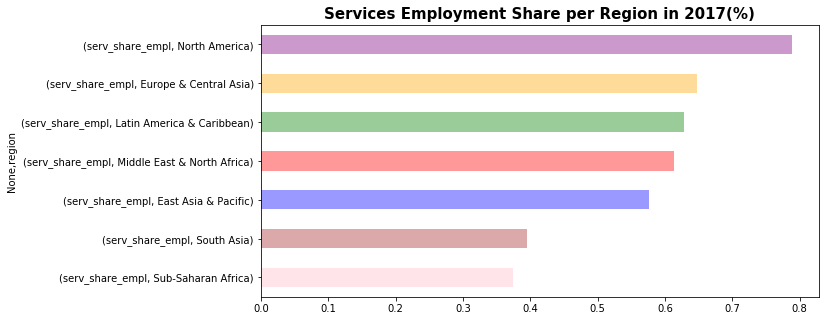

```python
sector_per_region.loc[2017,:].sort_values ().plot (kind = 'barh', color = ['pink', 'brown', 'blue','red','green',
                'orange','purple'], figsize = (10,5), alpha = 0.4)
plt.title ('Services Employment Share per Region in 2017(%)', fontweight = 'bold', fontsize = 15)
```

The U.S. and Canada present a similar share for the services sector regarding employment, as can be observed in the visualization below. Around 8 out of 10 employed workers from these countries performed an activity related to services in 2017.

The U.S. has presented a remarkable growth of the services sector since 1998, what may be related to the strong and constinuous growth of American technology companies in the last 2 decades. Many advancements in the tech arena have been born in the U.S., what might have fostered the service sector over the years.

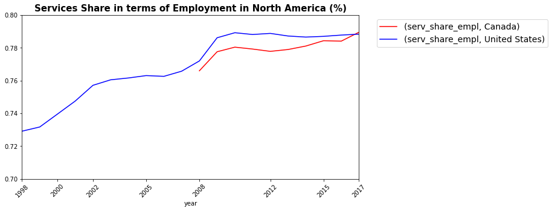

```python
# creating a dataframe with North America data
north_america = sectors[sectors['region']=='North America']

# table with the evolution per country in North America
countries_north_america =pd.pivot_table (north_america, index='year', values= ['serv_share_empl'],
                        columns =['country'] ,aggfunc='mean', fill_value=np.nan).loc[1998:2017,:]

# visualizing the evolution of Services share in terms of employment
countries_north_america.plot(rot=45, color=['red','blue'], xticks=[1998, 2000, 2002, 2005, 2008, 2012, 2015,2017],
                        figsize = (10,5), ylim = (0.70, 0.80)).legend(bbox_to_anchor=(1.04,1),
                        loc="upper left", fontsize = 14)
plt.title ('Services Share in terms of Employment in North America (%)', fontweight = 'bold', fontsize = 15)
```

### 3.4 Brazil Sectors Importance

Latin America & Caribbean is among the Top-3 regions in terms of services employment share. Brazil is the largest country of the region, with a population that surpasses 200 million.

As depicted in the figure below, services are the largest sector in Brazil, both in terms of GDP and employment. It accounts for 7 out of 10 employed workers in the country, much higher than the global average (less than 50%) and the Latin America & Caribbean region average (around 60%).

There seems to be a balance between how much the segments represent in terms of GDP and employment in the country. The industry represents around 20% of both GDP and Employment, while agriculture acounts for around 10%.

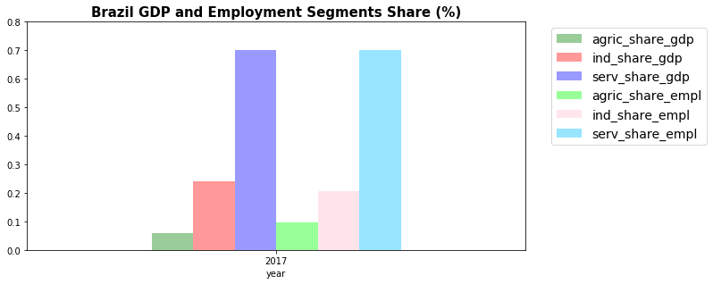

```python
# creating a datafram with Brazil data
brazil = sectors[sectors['country']=='Brazil']

# table with segments share evolution in Brazil
brazil_sectors =pd.pivot_table (brazil, index='year', values= ['agric_share_empl', 'ind_share_empl',
                        'serv_share_empl', 'agric_share_gdp', 'ind_share_gdp', 'serv_share_gdp'],
                        aggfunc='mean', fill_value=np.nan)

# plotting segments shares in 2017
brazil_sectors.loc[[2017], ['agric_share_gdp', 'ind_share_gdp', 'serv_share_gdp','agric_share_empl', 'ind_share_empl',
        'serv_share_empl', ]].plot (kind='bar', figsize = (10,4.7), rot=0, color = ['green', 'red', 'blue',
        'lime','pink', 'deepskyblue'], ylim = (0,0.8), alpha = 0.4).legend(bbox_to_anchor=(1.04,1),
        loc="upper left", fontsize = 14)
plt.title ('Brazil GDP and Employment Segments Share (%)', fontweight = 'bold', fontsize = 15)
```

As shown in the graph below, GDP in Brazil has been increasingly dependent on the services sector, apparently in detriment of the industry. Agriculture has been pretty much stable in terms of GDP over the years.

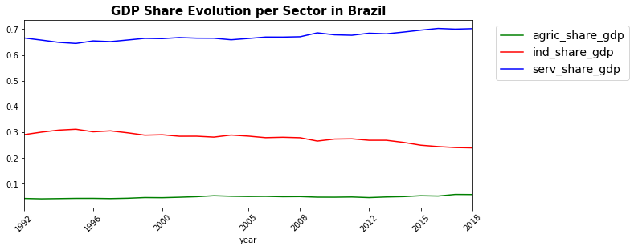

```python
# visualizing Brazil segments share evolution
brazil_sectors_gdp = brazil_sectors[['agric_share_gdp', 'ind_share_gdp','serv_share_gdp']].plot(color=['green',
            'red', 'blue'], rot=45, xticks=[1992, 1996, 2000, 2005, 2008, 2012, 2015,2018],
            figsize = (10,4.3)).legend(bbox_to_anchor=(1.04,1), loc="upper left", fontsize = 14)
plt.title ('GDP Share Evolution per Sector in Brazil', fontweight = 'bold', fontsize = 15)
```

As depicted in the figure below, there have been major changes in how employment is created in Brazil, especially after 2004. As noted earlier, the revolution in technology since the late 90's seems to have changed how the economy produces wealth and jobs all over the world, and the same applies to Brazil.

After 2011, we notice an acceleration of the services sector growth in the country. This happened at the same time some of the Brazilian unicorn start-ups were born. Ifood, an online food-delivery service (https://developers.facebook.com/success-stories/ifood/) was created in 2011, transforming the way people ordered food in Brazil. One year later, in 2012, 99-taxi (https://en.wikipedia.org/wiki/99_(app)), the first Brazilin ridesharing company, was founded to compete with Uber. In 2013, Nubank, a fintech which provided easy access for financial services at a low cost entered the market (https://en.wikipedia.org/wiki/Nubank).

Agriculture, converselly, has fallen drastically after 2004 in terms of its share of total employment. Considering that its participation in terms of GDP has been stable over the years, this sector seems to have reached enormous gains of productivity. With less and less people, the segment produces the same as in previous years.

The industry showed a negative trend after 2012, what might have been related to the economic hardship faced by the country since 2013.

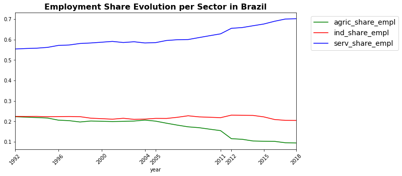

```python
# Visualizing sectors share trends in terms of employment
brazil_sectors_empl = brazil_sectors[['agric_share_empl', 'ind_share_empl',
                        'serv_share_empl']].plot(color=['green', 'red', 'blue'], rot=45,
                        xticks=[1992, 1996, 2000, 2004, 2005, 2011, 2012, 2015,2018],
                        figsize = (10,5)).legend(bbox_to_anchor=(1.04,1),
                        loc="upper left", fontsize = 14)
plt.title ('Employment Share Evolution per Sector in Brazil', fontweight = 'bold', fontsize = 16)
```

## Conclusions

The aim of this article is to shed light upon how employment and wealth dynamics have been changing in the last three decades. The analysis was based on World Bank data which includes the evolution of economic indicators from 169 countries from 1992 to 2018.

In the regional level, North America presented the highest share of workers employed in services (8 out of 10). This figures were similar for the U.S. and Canada. The sector has been continuously growing in the U.S. especially after 1998. The late 90's and early 2000's were marked by a revolution in the tech industry. American tech giants like Google and Amazon were created during these years. Moreover, technology started to be applied in novel ways which changed how people work and consume. For instance, ridesharing and content streaming gained momentum in the late 2000's, what might have further fostered the sector.

Europe & Central Asia and Latin America & Caribeean also stood out as highly developed in terms of the services sector. It comprised more than 60% of employed workers in these regions. More specifically, Brazil, the largest country in Latin America, presented 70% of its GDP and employment devoted to the sector.

Since 2004, the Brazilian economy has profoundly changed, being increasingly dependant upon the services sector. This happened mainly in detriment of agriculture. This latter has been decreasing since 2004 in terms of the number of employed workers dedicated to it. Nonetheless, it maintained the same share in terms of GDP. This reveals the enourmous gains in productivity that the agriculture sector achieved over the years.

In summary, global economy has faced profound changes in the last 25 years. Advances in technology and in the way people communicate have been deepply transforming how jobs and wealth are created. More and more people are performing activities related to services, while automation has continuously reduced the number of workers in agriculture and the industry. It is uncertain what the future economy will look like, but for coming years it seems that technology will continue to transform the way people make money and consume, what will probably keep fostering the growth of the services sector for years to come.